# Chapter 12 시계열 데이터

## 시간 범위의 주기 설정하기(p.263)

```python
print(pd.date_range('2017-01-01', '2017-01-07', freq='B'))  # freq='B' : 평일만 포함 , 세부 속성은 교재 확인
```

```
DatetimeIndex(['2017-01-02', '2017-01-03', '2017-01-04', '2017-01-05',
               '2017-01-06'],
              dtype='datetime64[ns]', freq='B')
```

## 에볼라의 확산 속도 비교하기(p264)

### 1. 날짜별 사망자 수 그래프 그리기

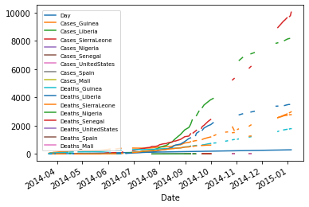

```python
import matplotlib.pyplot as plt

ebola.index = ebola['Date']
fig, ax = plt.subplots()
ax = ebola.iloc[0:, 1:].plot(ax=ax)
ax.legend(fontsize=7, loc=2, borderaxespad=1.)  # 범례의 글꼴 크기, 범례위치, 축과의 여백 지정
plt.show()
```

### 2. 앞의 plot은 각 나라별 ebola의 발생일이 달라 그래프의 그려지는 시점이 다름

### 발병기간을 비교하려면 동일 선성에 두고 플롯을 그려보야야 비교 가능!

### 각 나라별 발병일을 맨처음 발생한 Guinea와 동일한 위치로 이동

```python
print(ebola.tail())
```

```
                 Date  Day  Cases_Guinea  Cases_Liberia  Cases_SierraLeone  \
Date
2014-03-27 2014-03-27    5         103.0            8.0                6.0
2014-03-26 2014-03-26    4          86.0            NaN                NaN
2014-03-25 2014-03-25    3          86.0            NaN                NaN
2014-03-24 2014-03-24    2          86.0            NaN                NaN
2014-03-22 2014-03-22    0          49.0            NaN                NaN

            Cases_Nigeria  Cases_Senegal  Cases_UnitedStates  Cases_Spain  \
Date
2014-03-27            NaN            NaN                 NaN          NaN
2014-03-26            NaN            NaN                 NaN          NaN
2014-03-25            NaN            NaN                 NaN          NaN
2014-03-24            NaN            NaN                 NaN          NaN
2014-03-22            NaN            NaN                 NaN          NaN

            Cases_Mali  Deaths_Guinea  Deaths_Liberia  Deaths_SierraLeone  \
Date
2014-03-27         NaN           66.0             6.0                 5.0
2014-03-26         NaN           62.0             NaN                 NaN
2014-03-25         NaN           60.0             NaN                 NaN
2014-03-24         NaN           59.0             NaN                 NaN
2014-03-22         NaN           29.0             NaN                 NaN

            Deaths_Nigeria  Deaths_Senegal  Deaths_UnitedStates  Deaths_Spain  \
Date
2014-03-27             NaN             NaN                  NaN           NaN
2014-03-26             NaN             NaN                  NaN           NaN
2014-03-25             NaN             NaN                  NaN           NaN
2014-03-24             NaN             NaN                  NaN           NaN
2014-03-22             NaN             NaN                  NaN           NaN

            Deaths_Mali
Date
2014-03-27          NaN
2014-03-26          NaN
2014-03-25          NaN
2014-03-24          NaN
2014-03-22          NaN
```

### 3. 그래프를 그리기 위한 데이터프레임 준비하기

```python
# Date가 중간에 없는 날짜가 존재 - 모든 날짜를 다 생성해 주어야 정확한 날짜 비교 가능
ebola = pd.read_csv('../data/country_timeseries.csv',  parse_dates=['Date'])
print(ebola.head(10).iloc[:, :5])
print(ebola.tail(10).iloc[:, :5])
```

```
        Date  Day  Cases_Guinea  Cases_Liberia  Cases_SierraLeone
0 2015-01-05  289        2776.0            NaN            10030.0
1 2015-01-04  288        2775.0            NaN             9780.0
2 2015-01-03  287        2769.0         8166.0             9722.0
3 2015-01-02  286           NaN         8157.0                NaN
4 2014-12-31  284        2730.0         8115.0             9633.0
5 2014-12-28  281        2706.0         8018.0             9446.0
6 2014-12-27  280        2695.0            NaN             9409.0
7 2014-12-24  277        2630.0         7977.0             9203.0
8 2014-12-21  273        2597.0            NaN             9004.0
9 2014-12-20  272        2571.0         7862.0             8939.0
          Date  Day  Cases_Guinea  Cases_Liberia  Cases_SierraLeone
112 2014-04-04   13         143.0           18.0                2.0
113 2014-04-01   10         127.0            8.0                2.0
114 2014-03-31    9         122.0            8.0                2.0
115 2014-03-29    7         112.0            7.0                NaN
116 2014-03-28    6         112.0            3.0                2.0
117 2014-03-27    5         103.0            8.0                6.0
118 2014-03-26    4          86.0            NaN                NaN
119 2014-03-25    3          86.0            NaN                NaN
120 2014-03-24    2          86.0            NaN                NaN
121 2014-03-22    0          49.0            NaN                NaN
```

### 4. 기간의 최대값과 최소값 범위를 생성하여 새로운 인덱스로 만들면 중간에 없던 날짜들이 모두 생성됨

```python
ebola.index = ebola['Date']

new_idx = pd.date_range(ebola.index.min(), ebola.index.max())
```

```python
print(new_idx)
```

```
DatetimeIndex(['2014-03-22', '2014-03-23', '2014-03-24', '2014-03-25',
               '2014-03-26', '2014-03-27', '2014-03-28', '2014-03-29',
               '2014-03-30', '2014-03-31',
               ...
               '2014-12-27', '2014-12-28', '2014-12-29', '2014-12-30',
               '2014-12-31', '2015-01-01', '2015-01-02', '2015-01-03',
               '2015-01-04', '2015-01-05'],
              dtype='datetime64[ns]', length=290, freq='D')
```

### 5. 새로 생성된 new_idx 날짜가 에볼라 데이터에 있는 시간 순서와 반대로 생성되어 있으므로 시간 순서를 맞추기 위해 reversed

```python
new_idx = reversed(new_idx)
```

### 6. reindex() 이용하여 생성한 인덱스를 새로운 인덱스로 지정

```python
ebola = ebola.reindex(new_idx)
```

```python
print(ebola.head().iloc[:, :5])
```

```
                 Date    Day  Cases_Guinea  Cases_Liberia  Cases_SierraLeone
Date
2015-01-05 2015-01-05  289.0        2776.0            NaN            10030.0
2015-01-04 2015-01-04  288.0        2775.0            NaN             9780.0
2015-01-03 2015-01-03  287.0        2769.0         8166.0             9722.0
2015-01-02 2015-01-02  286.0           NaN         8157.0                NaN
2015-01-01        NaT    NaN           NaN            NaN                NaN
```

```python
print(ebola.tail().iloc[:, :5])
```

```
                 Date  Day  Cases_Guinea  Cases_Liberia  Cases_SierraLeone
Date
2014-03-26 2014-03-26  4.0          86.0            NaN                NaN
2014-03-25 2014-03-25  3.0          86.0            NaN                NaN
2014-03-24 2014-03-24  2.0          86.0            NaN                NaN
2014-03-23        NaT  NaN           NaN            NaN                NaN
2014-03-22 2014-03-22  0.0          49.0            NaN                NaN
```

### 7. 각 나라의 에볼라 발병일 옮기기

### last_valid_index(가장 오래된 데이터) , first_valid_index(가장 최근 데이터)

```python
last_valid = ebola.apply(pd.Series.last_valid_index)   # 각 나라별 최초 발병일
print(last_valid)
```

```
Date                  2014-03-22
Day                   2014-03-22
Cases_Guinea          2014-03-22
Cases_Liberia         2014-03-27
Cases_SierraLeone     2014-03-27
Cases_Nigeria         2014-07-23
Cases_Senegal         2014-08-31
Cases_UnitedStates    2014-10-01
Cases_Spain           2014-10-08
Cases_Mali            2014-10-22
Deaths_Guinea         2014-03-22
Deaths_Liberia        2014-03-27
Deaths_SierraLeone    2014-03-27
Deaths_Nigeria        2014-07-23
Deaths_Senegal        2014-09-07
Deaths_UnitedStates   2014-10-01
Deaths_Spain          2014-10-08
Deaths_Mali           2014-10-22
dtype: datetime64[ns]
```

```python
first_valid = ebola.apply(pd.Series.first_valid_index) # 각 나라별 최후의 발병일
print(first_valid)
```

```
Date                  2015-01-05
Day                   2015-01-05
Cases_Guinea          2015-01-05
Cases_Liberia         2015-01-03
Cases_SierraLeone     2015-01-05
Cases_Nigeria         2014-12-07
Cases_Senegal         2014-12-07
Cases_UnitedStates    2014-12-07
Cases_Spain           2014-12-07
Cases_Mali            2014-12-07
Deaths_Guinea         2015-01-05
Deaths_Liberia        2015-01-03
Deaths_SierraLeone    2015-01-05
Deaths_Nigeria        2014-12-07
Deaths_Senegal        2014-12-07
Deaths_UnitedStates   2014-12-07
Deaths_Spain          2014-12-07
Deaths_Mali           2014-12-07
dtype: datetime64[ns]
```

### 8. 에볼라 맨처음 발병일에서 각 나라별 최초 발병일을 빼줌

```python
earliest_date = ebola.index.min()
print(earliest_date)
```

```
2014-03-22 00:00:00
```

```python
shift_values = last_valid - earliest_date
print(shift_values)
```

```
Date                    0 days
Day                     0 days
Cases_Guinea            0 days
Cases_Liberia           5 days
Cases_SierraLeone       5 days
Cases_Nigeria         123 days
Cases_Senegal         162 days
Cases_UnitedStates    193 days
Cases_Spain           200 days
Cases_Mali            214 days
Deaths_Guinea           0 days
Deaths_Liberia          5 days
Deaths_SierraLeone      5 days
Deaths_Nigeria        123 days
Deaths_Senegal        169 days
Deaths_UnitedStates   193 days
Deaths_Spain          200 days
Deaths_Mali           214 days
dtype: timedelta64[ns]
```

### 9. 에볼라 발병일을 동일선상으로 맞추기 shift() : 지정한 일 수 만큼 이동

```python
# shift method : 지정된 일 수 만큼 이동(shift)시킨 후 딕셔너리에 저장
ebola_dict = {}
for idx, col in enumerate(ebola):
    d = shift_values[idx].days   #  일(days)로 변환한 값을 d에 저장
    shifted = ebola[col].shift(d)  # 현재 열을  d만큼 이동
    ebola_dict[col] = shifted
```

### 10. dataframe으로 만들기

```python
ebola_shift = pd.DataFrame(ebola_dict)
```

```python
print(ebola_shift.tail())
print(ebola.tail())
```

```
                 Date  Day  Cases_Guinea  Cases_Liberia  Cases_SierraLeone  \
Date
2014-03-26 2014-03-26  4.0          86.0            8.0                2.0
2014-03-25 2014-03-25  3.0          86.0            NaN                NaN
2014-03-24 2014-03-24  2.0          86.0            7.0                NaN
2014-03-23        NaT  NaN           NaN            3.0                2.0
2014-03-22 2014-03-22  0.0          49.0            8.0                6.0

            Cases_Nigeria  Cases_Senegal  Cases_UnitedStates  Cases_Spain  \
Date
2014-03-26            1.0            NaN                 1.0          1.0
2014-03-25            NaN            NaN                 NaN          NaN
2014-03-24            NaN            NaN                 NaN          NaN
2014-03-23            NaN            NaN                 NaN          NaN
2014-03-22            0.0            1.0                 1.0          1.0

            Cases_Mali  Deaths_Guinea  Deaths_Liberia  Deaths_SierraLeone  \
Date
2014-03-26         NaN           62.0             4.0                 2.0
2014-03-25         NaN           60.0             NaN                 NaN
2014-03-24         NaN           59.0             2.0                 NaN
2014-03-23         NaN            NaN             3.0                 2.0
2014-03-22         1.0           29.0             6.0                 5.0

            Deaths_Nigeria  Deaths_Senegal  Deaths_UnitedStates  Deaths_Spain  \
Date
2014-03-26             1.0             NaN                  0.0           1.0
2014-03-25             NaN             NaN                  NaN           NaN
2014-03-24             NaN             NaN                  NaN           NaN
2014-03-23             NaN             NaN                  NaN           NaN
2014-03-22             0.0             0.0                  0.0           1.0

            Deaths_Mali
Date
2014-03-26          NaN
2014-03-25          NaN
2014-03-24          NaN
2014-03-23          NaN
2014-03-22          1.0
                 Date  Day  Cases_Guinea  Cases_Liberia  Cases_SierraLeone  \
```

[output cut: 23 more lines]

```
            Deaths_Nigeria  Deaths_Senegal  Deaths_UnitedStates  Deaths_Spain  \
Date
2014-03-26             NaN             NaN                  NaN           NaN
2014-03-25             NaN             NaN                  NaN           NaN
2014-03-24             NaN             NaN                  NaN           NaN
2014-03-23             NaN             NaN                  NaN           NaN
2014-03-22             NaN             NaN                  NaN           NaN

            Deaths_Mali
Date
2014-03-26          NaN
2014-03-25          NaN
2014-03-24          NaN
2014-03-23          NaN
2014-03-22          NaN
```

### 12. 인덱스를 Day열로 지정하고 불필요한 Date, Day열 삭제

```python
ebola_shift.index = ebola_shift['Day']
ebola_shift = ebola_shift.drop(['Date', 'Day'], axis=1)

print(ebola_shift.tail())
print(ebola.tail())
```

```
     Cases_Guinea  Cases_Liberia  Cases_SierraLeone  Cases_Nigeria  \
Day
4.0          86.0            8.0                2.0            1.0
3.0          86.0            NaN                NaN            NaN
2.0          86.0            7.0                NaN            NaN
NaN           NaN            3.0                2.0            NaN
0.0          49.0            8.0                6.0            0.0

     Cases_Senegal  Cases_UnitedStates  Cases_Spain  Cases_Mali  \
Day
4.0            NaN                 1.0          1.0         NaN
3.0            NaN                 NaN          NaN         NaN
2.0            NaN                 NaN          NaN         NaN
NaN            NaN                 NaN          NaN         NaN
0.0            1.0                 1.0          1.0         1.0

     Deaths_Guinea  Deaths_Liberia  Deaths_SierraLeone  Deaths_Nigeria  \
Day
4.0           62.0             4.0                 2.0             1.0
3.0           60.0             NaN                 NaN             NaN
2.0           59.0             2.0                 NaN             NaN
NaN            NaN             3.0                 2.0             NaN
0.0           29.0             6.0                 5.0             0.0

     Deaths_Senegal  Deaths_UnitedStates  Deaths_Spain  Deaths_Mali
Day
4.0             NaN                  0.0           1.0          NaN
3.0             NaN                  NaN           NaN          NaN
2.0             NaN                  NaN           NaN          NaN
NaN             NaN                  NaN           NaN          NaN
0.0             0.0                  0.0           1.0          1.0
                 Date  Day  Cases_Guinea  Cases_Liberia  Cases_SierraLeone  \
Date
2014-03-26 2014-03-26  4.0          86.0            NaN                NaN
2014-03-25 2014-03-25  3.0          86.0            NaN                NaN
2014-03-24 2014-03-24  2.0          86.0            NaN                NaN
2014-03-23        NaT  NaN           NaN            NaN                NaN
2014-03-22 2014-03-22  0.0          49.0            NaN                NaN

            Cases_Nigeria  Cases_Senegal  Cases_UnitedStates  Cases_Spain  \
```

[output cut: 15 more lines]

```
            Deaths_Nigeria  Deaths_Senegal  Deaths_UnitedStates  Deaths_Spain  \
Date
2014-03-26             NaN             NaN                  NaN           NaN
2014-03-25             NaN             NaN                  NaN           NaN
2014-03-24             NaN             NaN                  NaN           NaN
2014-03-23             NaN             NaN                  NaN           NaN
2014-03-22             NaN             NaN                  NaN           NaN

            Deaths_Mali
Date
2014-03-26          NaN
2014-03-25          NaN
2014-03-24          NaN
2014-03-23          NaN
2014-03-22          NaN
```

### 13. 동일기준선상에서 플롯팅

[figure not shown]

```python
fig, ax = plt.subplots()
ax = ebola_shift.iloc[:, :].plot(ax=ax)
ax.legend(fontsize=7, loc=2, borderaxespad=0.)
plt.show()
```